# Lab 2

Saransh Rakshak

9/6/2024

## Packages and libraries

When you open an R session, a few libraries (base, stats, graphics) are already loaded. There are many other libraries available that contain functions for statistical analysis and datasets. CRAN is a repository from which these packages can be installed easily.

To load a library that is already installed, use the `library()` function. You need to do this each time you begin an R session (or at the start of an RMarkdown document that requires the library.).

Here’s an example: the dataset called `galaxies` is contained in the MASS package. It will not load without loading the library. Run the code below to see the error message.

```r
data(galaxies)
```

After you load the MASS library, it will work.

```r
library(MASS)
data(galaxies)  # this ''attaches'' the data set to your workspace.
head(galaxies)
```

```
## [1]  9172  9350  9483  9558  9775 10227
```

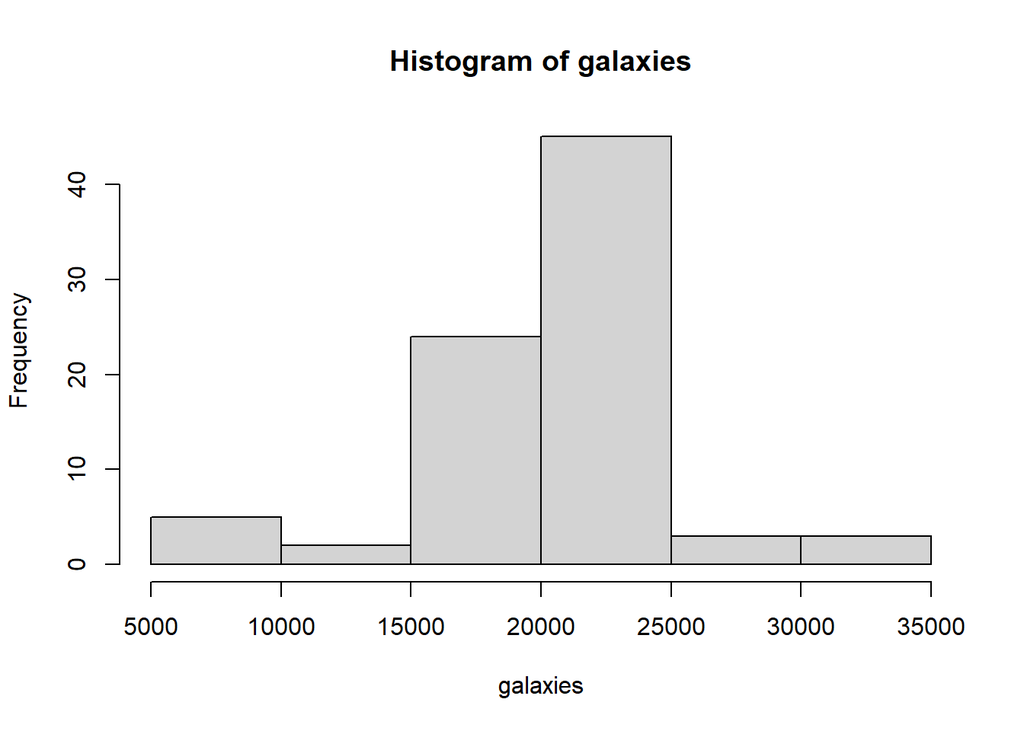

```r
hist(galaxies)  # remember the word for the shape of this distribution?
```

MASS is one of a small number of packages that are installed when R is installed. For most other packages, first install them using the function `install.packages()`. When R asks you to select a CRAN mirror, choose one that is geographically close to you. After you install the package once, you can then use the package by loading the library with the `library()` function at the beginning of each session.

Anyone can publish an R package on CRAN. If you are using a package to perform a statistical analysis, look at the documentation and make sure the package seems to come from a reliable source.

The code below would install and load the package “abind”, which I use often to store data or simulation results in multidimensional arrays. (Optional:) Try installing and loading a package of your choosing here. Some popular packages include “scales,” which lets you control scale and color transparency in a plot, or “reshape2,” which can turn wide data sets into tall ones.

```r
# Optional: replace "abind" in the code below with any package of your choosing and uncomment.

#install.packages("abind")
#library(abind)
```

You can also install a package with a point-and-click GUI by choosing “Tools” in the RStudio window and clicking “Install packages”.

## Displaying multiple panels in one plot

The `par` function lets you control the graphics created in R. It has many options that control the margins, scale, and titles of plots. The `mfrow` option allows you to arrange panels of plots in a grid. Set `mfrow=c(a,b)` to use a grid with $a$ rows and $b$ columns.

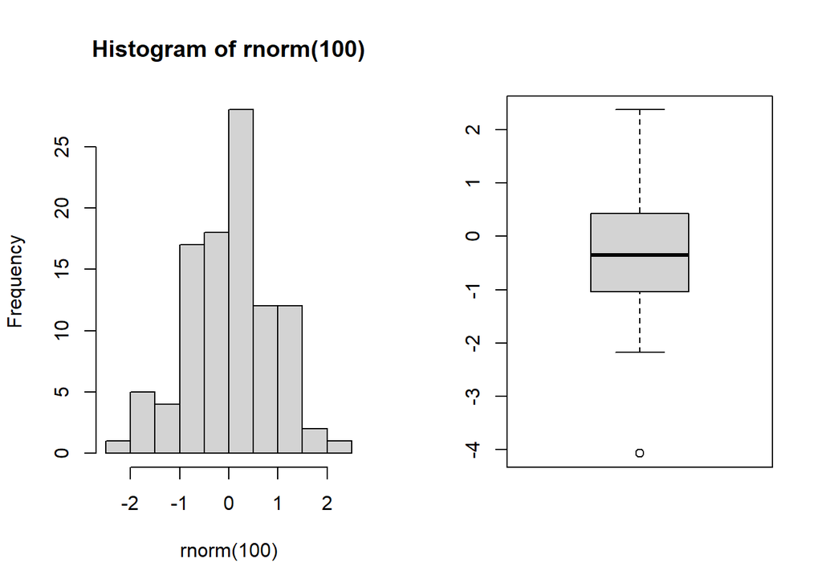

```r
par(mfrow=c(1,2))
hist(rnorm(100))
boxplot(rnorm(100))
```

The following code switches the arrangement to have two rows.

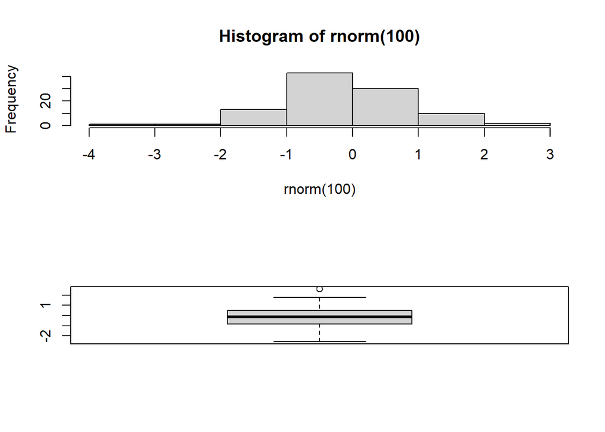

```r
par(mfrow=c(2,1))
hist(rnorm(100))
boxplot(rnorm(100))
```

Note: The methods for displaying multiple plots are quite different if you use ggplot2.

## Displaying multiple panels in one plot: R markdown

You can also put figures side by side in an R markdown document by specifying certain options when you define the code chunk. For example, the options `fig.show="hold"` and `out.width="50%"` puts two figures side by side.

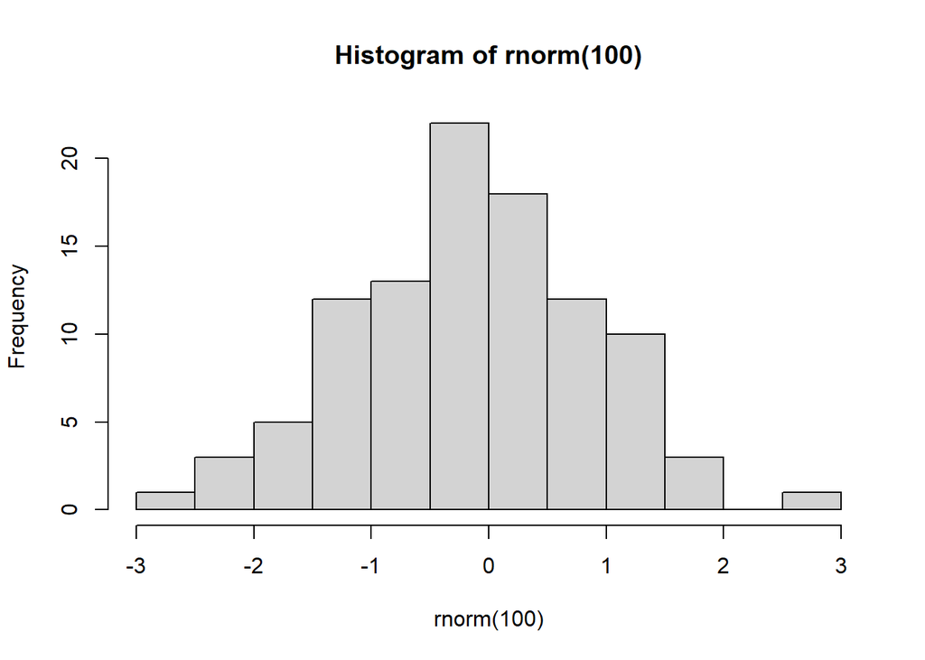

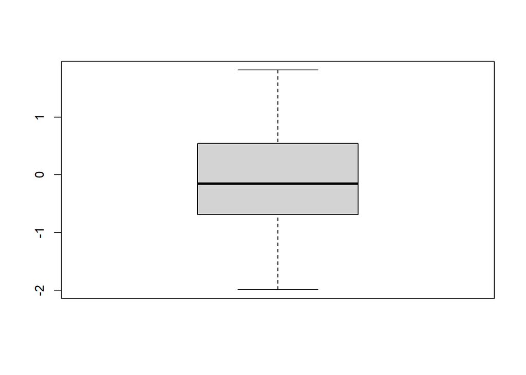

```r
hist(rnorm(100))
boxplot(rnorm(100))
```

## R with missing values

Some functions in R will not work in the presence of missing values. Most plotting functions will just ignore missings, but many calculations will return the value NA.

```r
# create a vector with missing values
x <- c(4,18,9,NA,0)
```

The vector `x` has an element whose value is NA, which is a special value in R representing a missing value. If we try to use the mean function on `x`, the answer is NA. The option `na.rm=T` can be used to ignore the missing values.

```r
mean(x)
```

```
## [1] NA
```

```r
mean(x, na.rm=T)  # use na.rm=T to ignore NAs
```

```
## [1] 7.75
```

You might get data in which the missing values are not coded as NA values. Here, `y` has a missing value but it is not treated as NA. Further, R thinks that `y` is a vector of character data because of the “no response” value.

```r
y <- c('no response',3,4,1,12)
is.na(y[1])  # returns TRUE if y[1] is NA
```

```
## [1] FALSE
```

```r
class(y)
```

```
## [1] "character"
```

The mean of y cannot be calculated, even with `na.rm=T`, because `y` is a character vector.

```r
mean(y, na.rm=T)
```

```
## [1] NA
```

The best way to prevent this is to ensure that R recognizes NAs when you first read in the data using the `na.strings` option in `read.csv`. Below is one quick and dirty way to fix it. The `as.numeric` function will turn `y` into a numeric vector. Any elements than cannot be turned into numeric values will become NAs. *Be careful with this approach:* it will not work as you expect on a variable whose class is `factor`, for example.

```r
y <- as.numeric(y)
y
```

```
## [1] NA  3  4  1 12
```

```r
class(y)
```

```
## [1] "numeric"
```

Missing values are addressed differently in functions of two variables, such as the `cor()` function. The argument `use = 'complete.obs'` will omit missing values. See the R documentation for different options for the “use” argument.

```r
cor(x, y, use='complete.obs')
```

```
## [1] -0.9122455
```

# Exercises

## Exercise 1: Explore associations in Airbnb data

Use the Airbnb data from last week, found in the file `airbnb_asheville.csv`. **Make sure to put all of your code in code chunks.**

The following R functions will help in answering the questions below: mean, median, quantile, boxplot, subset, table, prop.table.

1. Calculate the mean, median, and standard deviation of the variable `price` among only listings for which `room_Type` is `Entire home/apt`. Then calculate the mean, median, and standard deviation of the variable `price` among only listings for which `room_type` is `private room`. (You did this already last week. Try using `tapply` this time!)

**Answer:** Old Approach (R native):

```r
data <- read.csv("airbnb_asheville.csv")

# 'Entire home/apt'
full_house <- subset(data, room_type == "Entire home/apt")

mean(full_house$price)
```

```
## [1] 181.479
```

```r
median(full_house$price)
```

```
## [1] 139
```

```r
sd(full_house$price)
```

```
## [1] 155.9541
```

```r
# 'Private room'
private_house <- subset(data, room_type == "Private room")

mean(private_house$price)
```

```
## [1] 108.45
```

```r
median(private_house$price)
```

```
## [1] 70.5
```

```r
sd(private_house$price)
```

```
## [1] 134.1154
```

New Approach (tapply):

```r
data$room_type <- as.factor(data$room_type)

tapply(data$price, data$room_type, mean)
```

```
## Entire home/apt      Hotel room    Private room     Shared room
##         181.479         169.000         108.450          43.000
```

```r
tapply(data$price, data$room_type, median)
```

```
## Entire home/apt      Hotel room    Private room     Shared room
##           139.0           169.0            70.5            43.0
```

```r
tapply(data$price, data$room_type, sd)
```

```
## Entire home/apt      Hotel room    Private room     Shared room
##       155.95412        98.99495       134.11536              NA
```

2. Use boxplots or histograms to display the distribution of `price` grouped by `room_Type`. Based on the results in parts a and b, is price associated with room type? There is a code chunk below that gives an example of syntax to make grouped boxplots.

**Answer:**

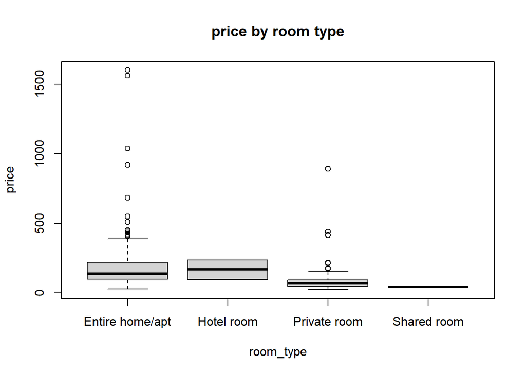

```r
boxplot(price ~ room_type, data = data, main = 'price by room type')
```

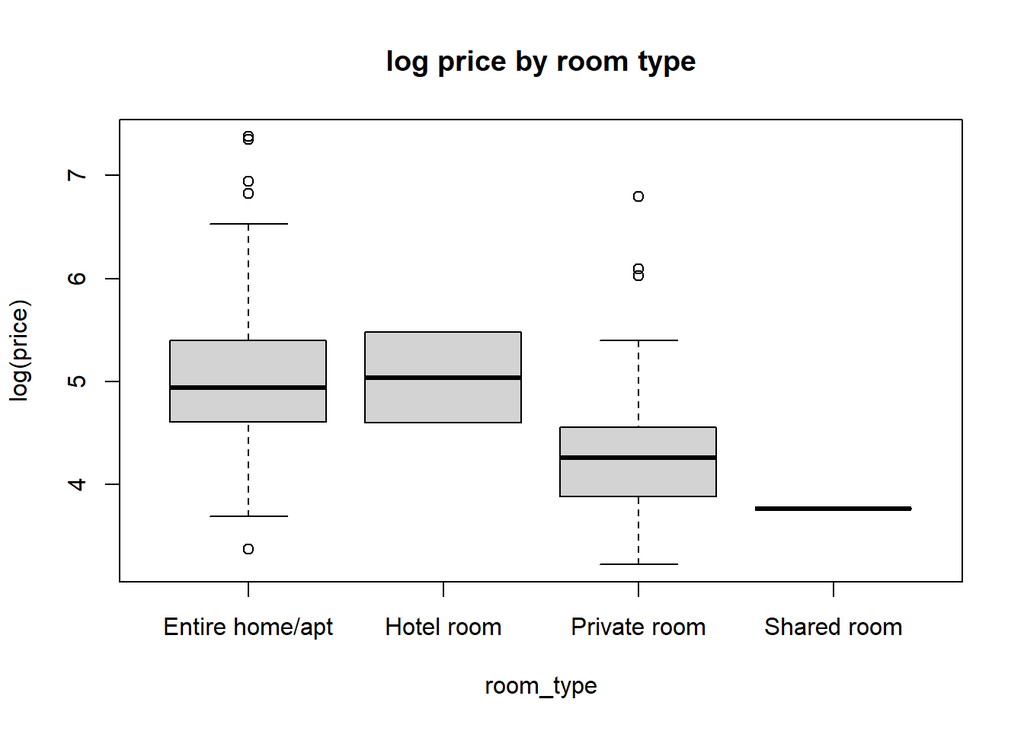

```r
boxplot(log(price)~room_type, data=data, main ='log price by room type')
```

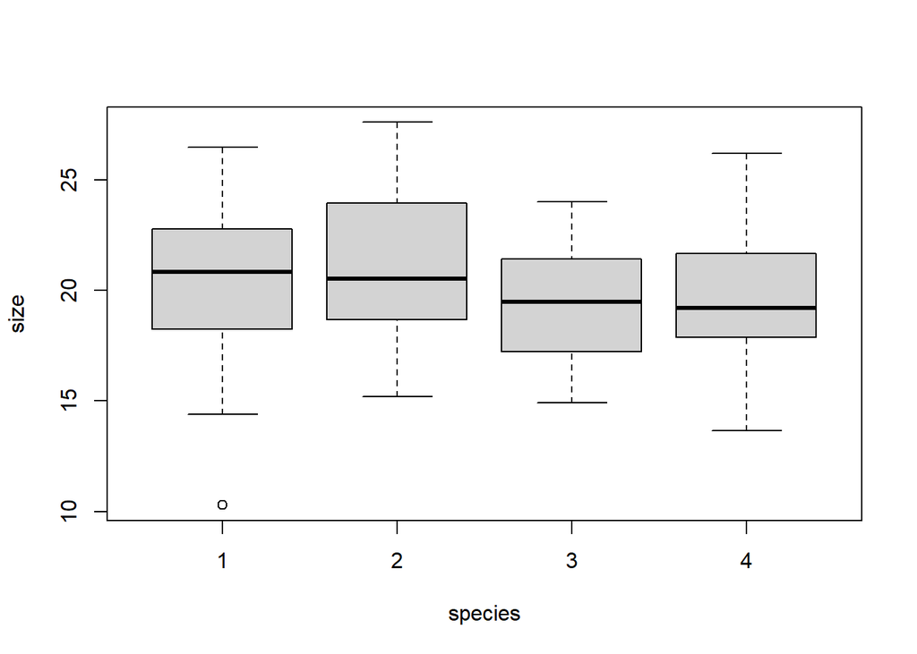

```r
# create a data frame of random numbers
randoms <- data.frame(size=rnorm(100,20,3), species=as.factor(sample(1:4,100,replace=TRUE)))

# the syntax a ~ b will make boxplots of variable "a"
# grouped by variable "b".
# in the "data=" put the name of the data frame
boxplot(size ~ species, data=randoms)
```

2. Calculate Pearson’s correlation between `price` and `number_of_reviews`. Use the `cor()` function. What does this suggest about the relationship between the variables? Make a scatterplot of `number_of_reviews` and `price`. Does their relationship look linear?